# Tarea 1

Jose Carlos de la Cruz Segovia

8 de marzo de 2021

Naturaleza: La mayor parte se utiliza en la producción de cemento para concreto (una mezcla hecha a base de cemento, agua, arena y grava). Este tipo de arena se extrae del fondo del océano, de ríos y de playas. La arena del desierto no se puede utilizar para fabricar concreto debido a su suavidad. Valor de uso: El concreto mayormente es utilizado para la construcción, aunque la arena, también se utiliza para regenerar playas y extender territorios. Por ejemplo, sirve para construir islas artificiales (como las Islas Palm en Dubái) o rellenar las costas para ganar terreno (como en Singapur). Valor de Cambio: Existen dos instancias que se encargan de la administración de las minas. Dichas instancias son: el comisariado ejidal y el comisariado de bienes comunales. Dentro de este marco, las concesiones para las minas se realizan directamente con cualquiera de los 2 comisariados. Para la primera asignación se cobra una cuota inicial de $200 000. La concesión tiene una duración que va de 3 a 6 años. Después del pago inicial, las empresas concesionarias tienen que pagar una cuota de $6 a $8 por cada m3 de material extraído. Este pago se realiza semanalmente a los comisariados, mismos que hacen cortes mensuales y las ganancias obtenidas se reparten entre los comuneros o ejidatarios. En el último pago efectuado en abril del 2008; cada comunero recibió alrededor de $1140 y por ejidatario el monto percibido fue de $430. (López Santiago, Valdivia Alcalá, Romo Lozano, Sandoval Villa, & Larqué Saavedra, 2010) Valor: La arena es el recurso más utilizado en la tierra después del aire y el agua. Cada casa, presa, camino, copa de vino o teléfono celular contiene este material. Sin embargo, incluso los elementos aparentemente interminables como la arena no pueden satisfacer la demanda actual de recursos. Aproximadamente 50 mil millones de toneladas de arena y grava se utilizan en todo el mundo cada año. (UNEP, 2019)

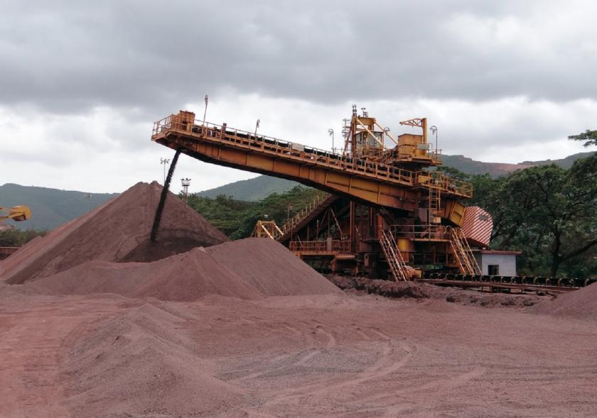

Fuente: UNEP

## Bibliografía

1. López Santiago, M. A., Valdivia Alcalá, R., Romo Lozano, J. L., Sandoval Villa, M., & Larqué Saavedra, B. S. (Junio de 2010). scielo. Obtenido de scielo: http://www.scielo.org.mx/scielo.php?script=sci_arttext&pid=S0187-57792010000300008
2. UNEP. (03 de Enero de 2019). UNEP. Obtenido de UNEP: https://www.unep.org/es/noticias-y-reportajes/reportajes/en-busca-de-la-extraccion-sostenible-de-arena#:~:text=La%20arena%20es%20el%20recurso,o%20celular%20contiene%20este%20material.&text=50.000%20millones%20de%20toneladas%20de,en%20el%20mundo%20cada%20a